# RandomForest RandomForest_ex_regression

```python
# データ処理のライブラリ
import pandas as pd
import numpy as np

# データ可視化のライブラリ
import matplotlib.pyplot as plt
import seaborn as sns

# 機械学習ライブラリ
from sklearn.model_selection import train_test_split
from sklearn.tree import DecisionTreeRegressor
from sklearn.ensemble import RandomForestRegressor
from sklearn.metrics import mean_squared_error

# 決定木の可視化ライブラリ
from sklearn import tree
import graphviz

# その他表示等の設定
pd.set_option('max_columns', 35)
pd.set_option('max_rows', 600)
sns.set_style("darkgrid")
```

```python
# CSVファイルの読み込み
kchouse = pd.read_csv('./house/kc_house_data.csv')
```

```python
# データセットの最初の5行を表示
kchouse.head()
```

|  | id | date | price | bedrooms | bathrooms | sqft_living | sqft_lot | floors | waterfront | view | condition | grade | sqft_above | sqft_basement | yr_built | yr_renovated | zipcode | lat | long | sqft_living15 | sqft_lot15 |
| --- | --- | --- | --- | --- | --- | --- | --- | --- | --- | --- | --- | --- | --- | --- | --- | --- | --- | --- | --- | --- | --- |
| 0 | 7129300520 | 20141013T000000 | 221900.0 | 3 | 1.00 | 1180 | 5650 | 1.0 | 0 | 0 | 3 | 7 | 1180 | 0 | 1955 | 0 | 98178 | 47.5112 | -122.257 | 1340 | 5650 |
| 1 | 6414100192 | 20141209T000000 | 538000.0 | 3 | 2.25 | 2570 | 7242 | 2.0 | 0 | 0 | 3 | 7 | 2170 | 400 | 1951 | 1991 | 98125 | 47.7210 | -122.319 | 1690 | 7639 |
| 2 | 5631500400 | 20150225T000000 | 180000.0 | 2 | 1.00 | 770 | 10000 | 1.0 | 0 | 0 | 3 | 6 | 770 | 0 | 1933 | 0 | 98028 | 47.7379 | -122.233 | 2720 | 8062 |
| 3 | 2487200875 | 20141209T000000 | 604000.0 | 4 | 3.00 | 1960 | 5000 | 1.0 | 0 | 0 | 5 | 7 | 1050 | 910 | 1965 | 0 | 98136 | 47.5208 | -122.393 | 1360 | 5000 |
| 4 | 1954400510 | 20150218T000000 | 510000.0 | 3 | 2.00 | 1680 | 8080 | 1.0 | 0 | 0 | 3 | 8 | 1680 | 0 | 1987 | 0 | 98074 | 47.6168 | -122.045 | 1800 | 7503 |

```python
# データセットの基本統計量を表示
kchouse.describe()
```

|  | id | price | bedrooms | bathrooms | sqft_living | sqft_lot | floors | waterfront | view | condition | grade | sqft_above | sqft_basement | yr_built | yr_renovated | zipcode | lat | long | sqft_living15 | sqft_lot15 |
| --- | --- | --- | --- | --- | --- | --- | --- | --- | --- | --- | --- | --- | --- | --- | --- | --- | --- | --- | --- | --- |
| count | 2.161300e+04 | 2.161300e+04 | 21613.000000 | 21613.000000 | 21613.000000 | 2.161300e+04 | 21613.000000 | 21613.000000 | 21613.000000 | 21613.000000 | 21613.000000 | 21613.000000 | 21613.000000 | 21613.000000 | 21613.000000 | 21613.000000 | 21613.000000 | 21613.000000 | 21613.000000 | 21613.000000 |
| mean | 4.580302e+09 | 5.400881e+05 | 3.370842 | 2.114757 | 2079.899736 | 1.510697e+04 | 1.494309 | 0.007542 | 0.234303 | 3.409430 | 7.656873 | 1788.390691 | 291.509045 | 1971.005136 | 84.402258 | 98077.939805 | 47.560053 | -122.213896 | 1986.552492 | 12768.455652 |
| std | 2.876566e+09 | 3.671272e+05 | 0.930062 | 0.770163 | 918.440897 | 4.142051e+04 | 0.539989 | 0.086517 | 0.766318 | 0.650743 | 1.175459 | 828.090978 | 442.575043 | 29.373411 | 401.679240 | 53.505026 | 0.138564 | 0.140828 | 685.391304 | 27304.179631 |
| min | 1.000102e+06 | 7.500000e+04 | 0.000000 | 0.000000 | 290.000000 | 5.200000e+02 | 1.000000 | 0.000000 | 0.000000 | 1.000000 | 1.000000 | 290.000000 | 0.000000 | 1900.000000 | 0.000000 | 98001.000000 | 47.155900 | -122.519000 | 399.000000 | 651.000000 |
| 25% | 2.123049e+09 | 3.219500e+05 | 3.000000 | 1.750000 | 1427.000000 | 5.040000e+03 | 1.000000 | 0.000000 | 0.000000 | 3.000000 | 7.000000 | 1190.000000 | 0.000000 | 1951.000000 | 0.000000 | 98033.000000 | 47.471000 | -122.328000 | 1490.000000 | 5100.000000 |
| 50% | 3.904930e+09 | 4.500000e+05 | 3.000000 | 2.250000 | 1910.000000 | 7.618000e+03 | 1.500000 | 0.000000 | 0.000000 | 3.000000 | 7.000000 | 1560.000000 | 0.000000 | 1975.000000 | 0.000000 | 98065.000000 | 47.571800 | -122.230000 | 1840.000000 | 7620.000000 |
| 75% | 7.308900e+09 | 6.450000e+05 | 4.000000 | 2.500000 | 2550.000000 | 1.068800e+04 | 2.000000 | 0.000000 | 0.000000 | 4.000000 | 8.000000 | 2210.000000 | 560.000000 | 1997.000000 | 0.000000 | 98118.000000 | 47.678000 | -122.125000 | 2360.000000 | 10083.000000 |
| max | 9.900000e+09 | 7.700000e+06 | 33.000000 | 8.000000 | 13540.000000 | 1.651359e+06 | 3.500000 | 1.000000 | 4.000000 | 5.000000 | 13.000000 | 9410.000000 | 4820.000000 | 2015.000000 | 2015.000000 | 98199.000000 | 47.777600 | -121.315000 | 6210.000000 | 871200.000000 |

```python
# 不要なカラムをデータセットから削除
kchouse = kchouse.drop(['id','date'], axis=1)
```

```python
# 寝室の数（bedrooms）を基軸にグルーピング
kchouse_m_bedrooms = kchouse.groupby('bedrooms', as_index=True).median()
kchouse_m_bedrooms.head()
```

| bedrooms | price | bathrooms | sqft_living | sqft_lot | floors | waterfront | view | condition | grade | sqft_above | sqft_basement | yr_built | yr_renovated | zipcode | lat | long | sqft_living15 | sqft_lot15 |
| --- | --- | --- | --- | --- | --- | --- | --- | --- | --- | --- | --- | --- | --- | --- | --- | --- | --- | --- |
| 0 | 288000.0 | 0.0 | 1470.0 | 5900.0 | 2.0 | 0.0 | 0.0 | 3.0 | 7.0 | 1470.0 | 0.0 | 1990.0 | 0.0 | 98065.0 | 47.52610 | -122.168 | 1810.0 | 7200.0 |
| 1 | 299000.0 | 1.0 | 780.0 | 5750.0 | 1.0 | 0.0 | 0.0 | 3.0 | 6.0 | 760.0 | 0.0 | 1940.0 | 0.0 | 98116.0 | 47.56210 | -122.315 | 1360.0 | 5650.0 |
| 2 | 374000.0 | 1.0 | 1140.0 | 5244.0 | 1.0 | 0.0 | 0.0 | 3.0 | 7.0 | 1010.0 | 0.0 | 1948.0 | 0.0 | 98116.0 | 47.60285 | -122.316 | 1430.0 | 5400.0 |
| 3 | 413000.0 | 2.0 | 1680.0 | 7629.5 | 1.0 | 0.0 | 0.0 | 3.0 | 7.0 | 1440.0 | 0.0 | 1976.0 | 0.0 | 98059.0 | 47.56505 | -122.231 | 1720.0 | 7688.5 |
| 4 | 549997.5 | 2.5 | 2410.0 | 8100.0 | 2.0 | 0.0 | 0.0 | 3.0 | 8.0 | 2080.0 | 0.0 | 1980.0 | 0.0 | 98056.0 | 47.57110 | -122.192 | 2190.0 | 8000.0 |

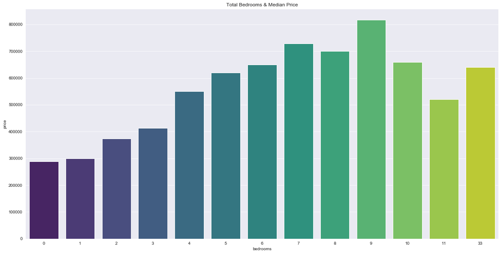

```python
# 寝室の数と価格のグラフ
plt.figure(figsize=(20,10))
plt.title('Total Bedrooms & Median Price')
sns.barplot(x=kchouse_m_bedrooms.index,y='price', data=kchouse_m_bedrooms, palette = 'viridis')

# X軸が寝室の数、Y軸が物件の中央値となります。
# 全体的な傾向として寝室の数が9つまでは物件の価格は高くなる傾向にあり、それ以降は価格が下がる傾向にある
```

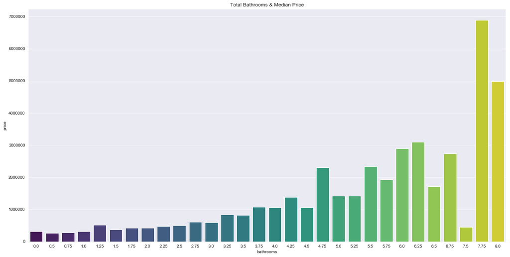

```python
# トイレの数（bathrooms)を基軸に中央値でグルーピング
kchouse_m_bathrooms= kchouse.groupby('bathrooms', as_index=True).median()

# トイレの数と価格の中央値のグラフ
plt.figure(figsize=(20,10))
plt.title('Total Bathrooms & Median Price')
sns.barplot(x=kchouse_m_bathrooms.index,y='price', data=kchouse_m_bathrooms, palette = 'viridis')
```

寝室の数と同様にトイレの数も増えれば増えるほど物件の価格は上昇する傾向にあります。トイレの数が7つ以上の物件があるのが驚きですね。実際データフレームで何軒該当するか確認してみましょう。

```python
# トイレの数（bathrooms）が7以上
kchouse[kchouse['bathrooms'] > 6]
```

|  | price | bedrooms | bathrooms | sqft_living | sqft_lot | floors | waterfront | view | condition | grade | sqft_above | sqft_basement | yr_built | yr_renovated | zipcode | lat | long | sqft_living15 | sqft_lot15 |
| --- | --- | --- | --- | --- | --- | --- | --- | --- | --- | --- | --- | --- | --- | --- | --- | --- | --- | --- | --- |
| 4024 | 800000.0 | 7 | 6.75 | 7480 | 41664 | 2.0 | 0 | 2 | 3 | 11 | 5080 | 2400 | 1953 | 0 | 98166 | 47.4643 | -122.368 | 2810 | 33190 |
| 7252 | 7700000.0 | 6 | 8.00 | 12050 | 27600 | 2.5 | 0 | 3 | 4 | 13 | 8570 | 3480 | 1910 | 1987 | 98102 | 47.6298 | -122.323 | 3940 | 8800 |
| 8092 | 4668000.0 | 5 | 6.75 | 9640 | 13068 | 1.0 | 1 | 4 | 3 | 12 | 4820 | 4820 | 1983 | 2009 | 98040 | 47.5570 | -122.210 | 3270 | 10454 |
| 8546 | 450000.0 | 9 | 7.50 | 4050 | 6504 | 2.0 | 0 | 0 | 3 | 7 | 4050 | 0 | 1996 | 0 | 98144 | 47.5923 | -122.301 | 1448 | 3866 |
| 9254 | 6885000.0 | 6 | 7.75 | 9890 | 31374 | 2.0 | 0 | 4 | 3 | 13 | 8860 | 1030 | 2001 | 0 | 98039 | 47.6305 | -122.240 | 4540 | 42730 |
| 12777 | 2280000.0 | 7 | 8.00 | 13540 | 307752 | 3.0 | 0 | 4 | 3 | 12 | 9410 | 4130 | 1999 | 0 | 98053 | 47.6675 | -121.986 | 4850 | 217800 |
| 14556 | 2888000.0 | 5 | 6.25 | 8670 | 64033 | 2.0 | 0 | 4 | 3 | 13 | 6120 | 2550 | 1965 | 2003 | 98177 | 47.7295 | -122.372 | 4140 | 81021 |
| 18302 | 3300000.0 | 5 | 6.25 | 8020 | 21738 | 2.0 | 0 | 0 | 3 | 11 | 8020 | 0 | 2001 | 0 | 98006 | 47.5675 | -122.189 | 4160 | 18969 |
| 20578 | 1180000.0 | 6 | 6.50 | 6260 | 10955 | 2.0 | 0 | 0 | 3 | 11 | 4840 | 1420 | 2007 | 0 | 98075 | 47.5947 | -122.039 | 2710 | 12550 |
| 21506 | 2238890.0 | 5 | 6.50 | 7270 | 130017 | 2.0 | 0 | 0 | 3 | 12 | 6420 | 850 | 2010 | 0 | 98027 | 47.5371 | -121.982 | 1800 | 44890 |

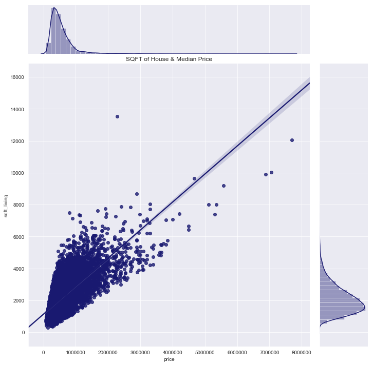

```python
# 価格と物件面積の散布図
sns.jointplot(x='price',y='sqft_living', data = kchouse, kind = 'reg', size = 10,  color = 'midnightblue')
plt.title('SQFT of House & Median Price')
```

X軸が物件の価格（price）でY軸が物件面積（sqft_living）となります。全体の傾向として価格の上昇に伴い物件面積も増えていますので「正の線形関係」があるといえます。

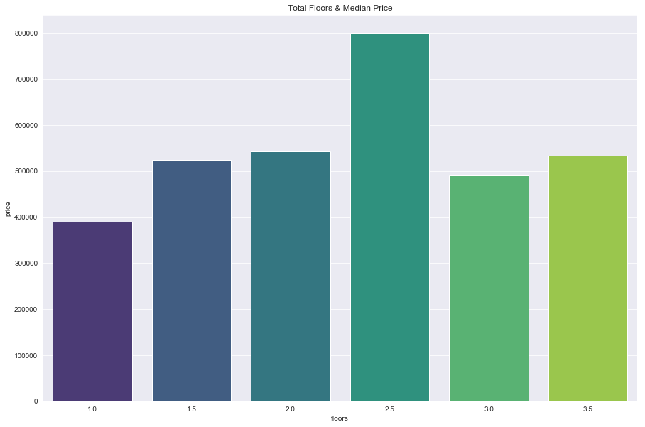

```python
# 物件の階数（floors）を基軸に中央値でグルーピング
kchouse_m_floors = kchouse.groupby('floors', as_index=True).median()

# 物件の階数と価格の中央値のグラフ
plt.figure(figsize=(15,10))
plt.title('Total Floors & Median Price')
sns.barplot(x=kchouse_m_floors.index,y='price', data=kchouse_m_floors, palette = 'viridis')
```

どうやらこちらの特徴量はターゲット（物件の価格）に対して明確な関係性が少なさそうです。つまり特徴量を単体として捉えるとモデルに対してはさほど役に立たない可能性があるといえます。

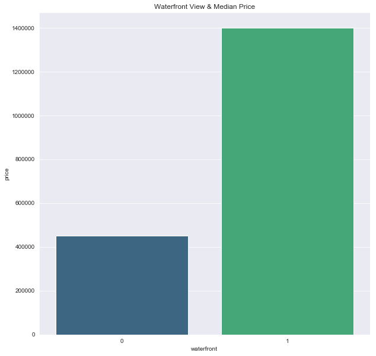

```python
# 湖岸の景色の有無（waterfront）を基軸に中央値でグルーピング
kchouse_m_waterfront = kchouse.groupby('waterfront', as_index=True).median()

# 湖岸の景色の有無と価格の中央値のグラフ
plt.figure(figsize=(10,10))
plt.title('Waterfront View & Median Price')
sns.barplot(x=kchouse_m_waterfront.index,y='price', data=kchouse_m_waterfront, palette= 'viridis')
```

明確に物件価格に違いがみられます。物件の価格は湖岸に面している、つまり水辺の景色がある物件の方が高い傾向にあるようです。

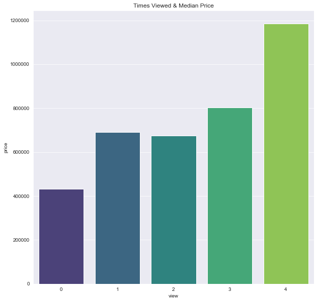

```python
# 内見された数（views）を基軸に中央値でグルーピング
kchouse_m_view = kchouse.groupby('view', as_index=True).median()

# 内見された数と価格の中央値のグラフ
plt.figure(figsize=(10,10))
plt.title('Times Viewed & Median Price')
sns.barplot(x=kchouse_m_view.index,y='price', data=kchouse_m_view, palette= 'viridis')
```

こちらも比較的強い相関関係が見て取れます。内見の数が多ければ多いほど、売却された価格の中央値は高くなる傾向にあります。

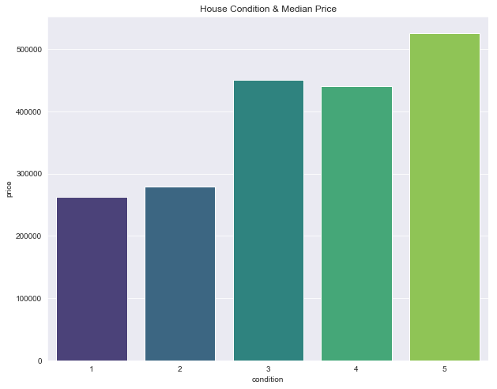

```python
# 物件のコンディション（condition）を基軸に中央値でグルーピング
kchouse_m_condition = kchouse.groupby('condition', as_index=True).median()

# 物件のコンディションと価格の中央値のグラフ
plt.figure(figsize=(10,8))
plt.title('House Condition & Median Price')
sns.barplot(x=kchouse_m_condition.index,y='price', data=kchouse_m_condition, palette= 'viridis')
```

コンディションと価格の関係をみてみると三段階になっているのが確認できます。コンディション評価が1と2はほぼ同等です。さらに３と４もほぼ同様の価格なのがわかります。

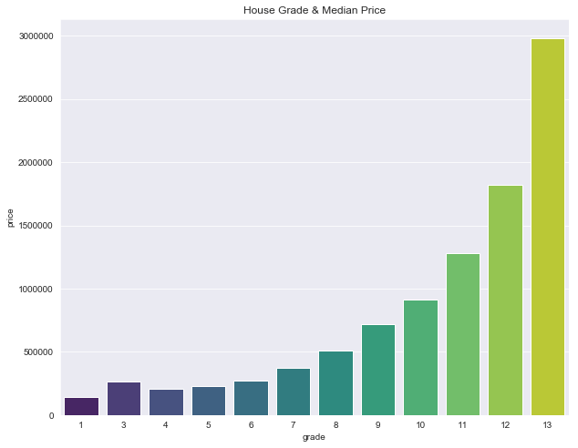

```python
# 物件のグレード（grade）を基軸に中央値でグルーピング
kchouse_m_grade = kchouse.groupby('grade', as_index=True).median()

# 物件のグレードと価格の中央値のグラフ
plt.figure(figsize=(10,8))
plt.title('House Grade & Median Price')
sns.barplot(x=kchouse_m_grade.index,y='price', data=kchouse_m_grade, palette= 'viridis')
```

グレードの「３」と「4」を除けばグレードが上がるたびに物件の価格も増えているのが確認できます。特にグレード12とグレード13の増加幅は非常に高いですね。

地上部広さ（sqft_above）

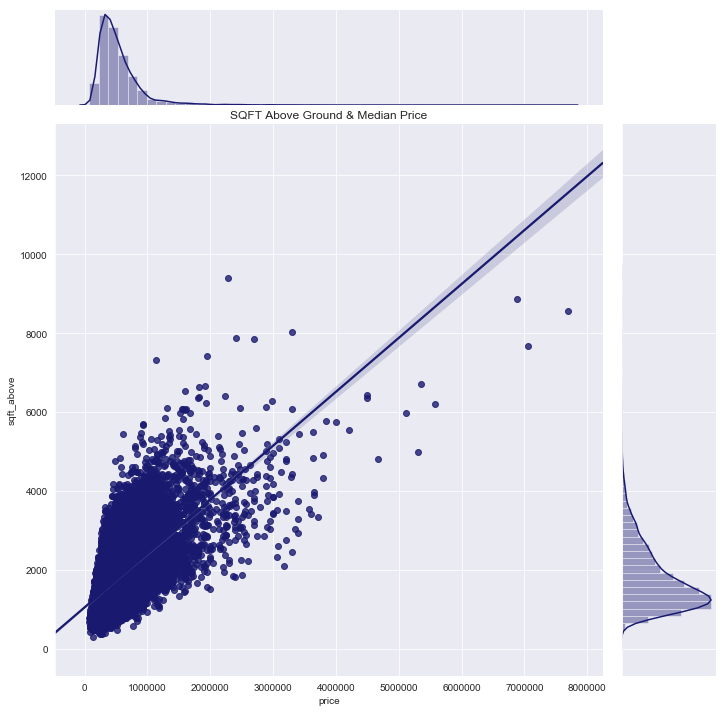

```python
# 物件地上部の広さと価格の中央値のグラフ
sns.jointplot(x='price',y='sqft_above', data = kchouse, kind = 'reg', size = 10, color = 'midnightblue')
plt.title('SQFT Above Ground & Median Price')
```

X軸が物件の価格（Price）でY軸が物件の地上部の広さ（sqft_above）です。比較的、綺麗な線形関係があるのが確認できます。

地下室広さ（sqft_basement） 物件に地下室がある場合、その地下室の広さを示す特徴量です。日本の戸建で地下室は珍しいですが、アメリカでは地下室を洗濯室や物置にする戸建が普及しています。

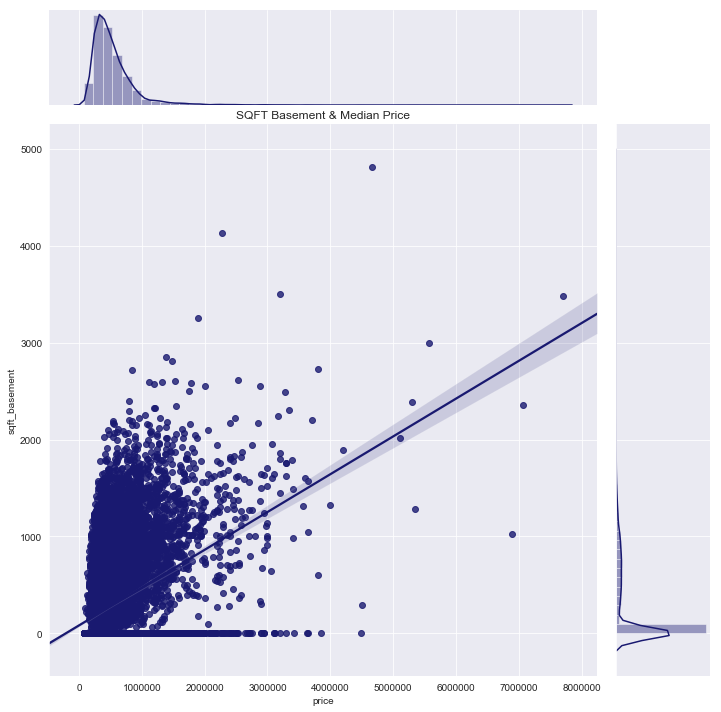

```python
# 地下室の広さと価格の中央値のグラフ
sns.jointplot(x='price',y='sqft_basement', data = kchouse, kind = 'reg', size = 10, color = 'midnightblue')
plt.title('SQFT Basement & Median Price')
```

前項の地上部の広さと似たような分布をしているのが確認できます。ただし地下室の広さが0、つまり地下室がない物件も多数あり、それらがグラフの0部分に多数マークされているのが確認できます。

地下室がない物件（つまりsqft_basement=0）がデータにどれくらいの割合で含まれているのか確認してみましょう。全データが21,613件ですので地下室がない物件の割合（%)を計算します。

```python
# 地下室がない物件の割合を計算
float(kchouse['sqft_basement'][kchouse['sqft_basement'] == 0].count()) / 21613 * 100
```

```
60.73196687179012
```

こちらのデータでは約60％は地下室がない物件のようです。つまり40％は地下室があるわけです。日本では珍しい地下室ですがアメリカでは普及しているのが解ります。

建造された年（yr_built）

こちらは各物件の建造された西暦です。現在の西暦から引けば日本でも馴染みのある「築年数」が算出することが可能です。それでは建造された年と物件の価格の関係性を確認してみましょう。

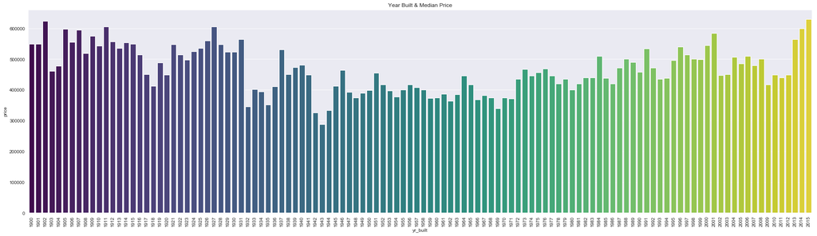

```python
# 建造された年（yr_built）を基軸に中央値でグルーピング
kchouse_m_yr_built = kchouse.groupby('yr_built', as_index=True).median()

# 建造された年と価格の中央値のグラフ
plt.figure(figsize=(30,8))
plt.xticks(rotation=90)
sns.barplot(x=kchouse_m_yr_built.index,y='price', data=kchouse_m_yr_built, palette= 'viridis')
plt.title('Year Built & Median Price')
```

これは少し意外なデータですね。一般的に築年数が高いほど古い家ということで価格が下がり、築年数が浅ければ浅いほど価格は高くなる傾向にあると思い込んでいましたが、本データではそのような傾向は無さそうです。

EDAを行うことで、このようにデータに対しての思い込みや既成概念を確認することが可能です。

リフォームされた年（yr_renovated）

最後に物件がリフォームされた年と価格の関係性を可視化しましょう。

こちらの特徴量ですが値が「0」とある物件はリフォームが一度も実施されたことがないことを表します。

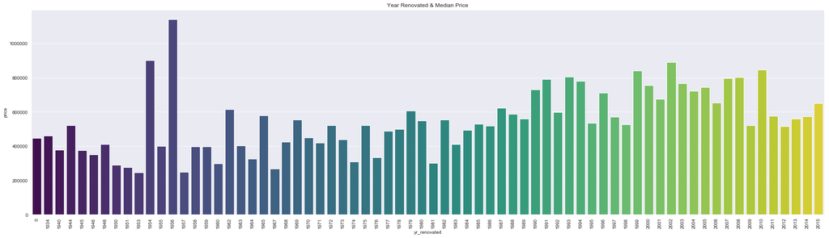

```python
# 建造された年（yr_built）を基軸に中央値でグルーピング
kchouse_m_yr_ren = kchouse.groupby('yr_renovated', as_index=True).median().sort_values(by='price',ascending=False)

# 建造された年と価格の中央値のグラフ
plt.figure(figsize=(30,8))
plt.xticks(rotation=90)
sns.barplot(x=kchouse_m_yr_ren.index,y='price', data=kchouse_m_yr_ren, palette= 'viridis')
plt.title('Year Renovated & Median Price')
```

データ全体でのリフォーム実施の割合を確認してみましょう。下記のコードで確認できる通り約95.77%はリフォームがされていない物件となります。

```python
# リフォームしていない物件の割合を計算
float(kchouse['yr_renovated'][kchouse['yr_renovated'] == 0].count()) / 21613 * 100
```

```
95.77106371165502
```

本チャプターのEDA(探索的データ解析）ではデータに含まれる特徴量とターゲットの関係性を可視化しました。 実社会の機械学習実装プロセスではより深くかつ幅広いデータ解析が必要となります。

3つの特徴量のアイデアを実装

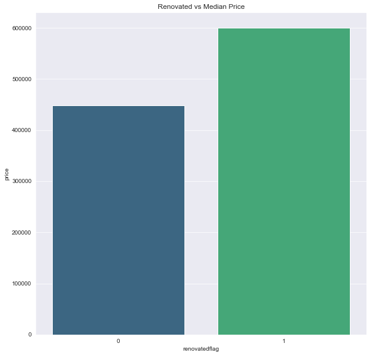

```python
# （その１）リフォーム実施フラグの処理
kchouse['renovatedflag'] = np.where(kchouse['yr_renovated'] == 0 , 0, 1)

# リフォームフラグと価格中央値の可視化
ren_flag = kchouse.groupby('renovatedflag', as_index=True).median()
plt.figure(figsize=(10,10))
sns.barplot(x=ren_flag.index,y='price', data=ren_flag, palette= 'viridis')
plt.title('Renovated vs Median Price')
```

リフォームの実施有無に対しての価格の中央値

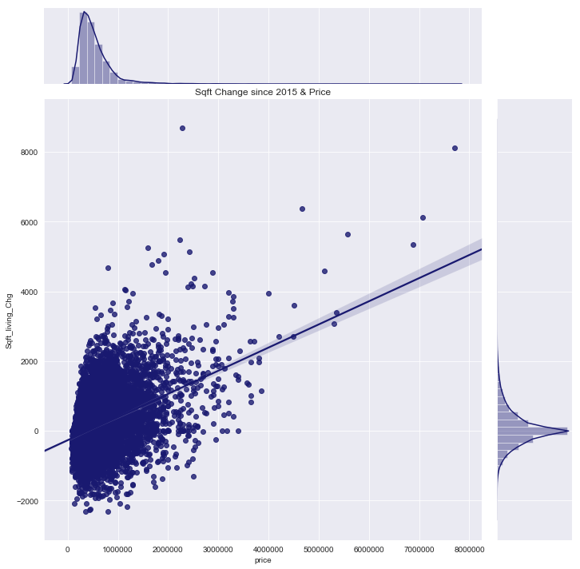

```python
# （その2）物件面積の変化量の処理
kchouse['Sqft_living_Chg'] = kchouse['sqft_living'] - kchouse['sqft_living15']

# 物件面積の変化量と価格の可視化
sns.jointplot(x='price',y='Sqft_living_Chg', data = kchouse, kind = 'reg', size = 10, color = 'midnightblue')
plt.title('Sqft Change since 2015 & Price')
```

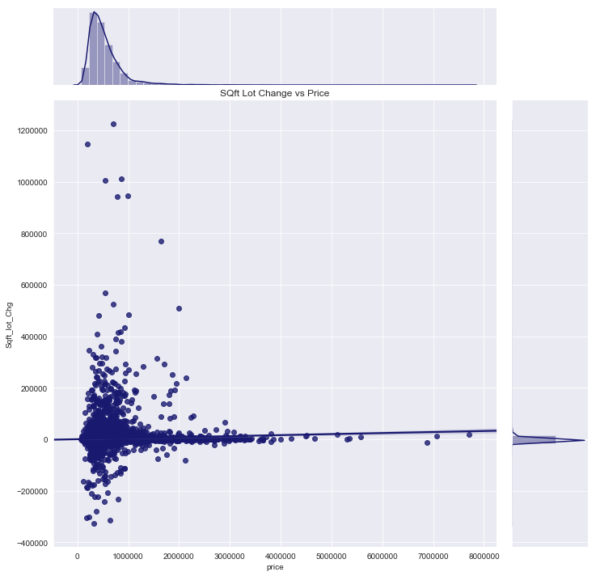

```python
# （その3）駐車場面積の変化量
kchouse['Sqft_lot_Chg'] = kchouse['sqft_lot'] - kchouse['sqft_lot15']

# 駐車場面積の変化量と価格の可視化
sns.jointplot(x='price',y='Sqft_lot_Chg', data = kchouse, kind = 'reg', size = 10, color = 'midnightblue')
plt.title('SQft Lot Change vs Price')
```

```python
# データセットの確認
kchouse.head()
```

|  | price | bedrooms | bathrooms | sqft_living | sqft_lot | floors | waterfront | view | condition | grade | sqft_above | sqft_basement | yr_built | yr_renovated | zipcode | lat | long | sqft_living15 | sqft_lot15 | renovatedflag | Sqft_living_Chg | Sqft_lot_Chg |
| --- | --- | --- | --- | --- | --- | --- | --- | --- | --- | --- | --- | --- | --- | --- | --- | --- | --- | --- | --- | --- | --- | --- |
| 0 | 221900.0 | 3 | 1.00 | 1180 | 5650 | 1.0 | 0 | 0 | 3 | 7 | 1180 | 0 | 1955 | 0 | 98178 | 47.5112 | -122.257 | 1340 | 5650 | 0 | -160 | 0 |
| 1 | 538000.0 | 3 | 2.25 | 2570 | 7242 | 2.0 | 0 | 0 | 3 | 7 | 2170 | 400 | 1951 | 1991 | 98125 | 47.7210 | -122.319 | 1690 | 7639 | 1 | 880 | -397 |
| 2 | 180000.0 | 2 | 1.00 | 770 | 10000 | 1.0 | 0 | 0 | 3 | 6 | 770 | 0 | 1933 | 0 | 98028 | 47.7379 | -122.233 | 2720 | 8062 | 0 | -1950 | 1938 |
| 3 | 604000.0 | 4 | 3.00 | 1960 | 5000 | 1.0 | 0 | 0 | 5 | 7 | 1050 | 910 | 1965 | 0 | 98136 | 47.5208 | -122.393 | 1360 | 5000 | 0 | 600 | 0 |
| 4 | 510000.0 | 3 | 2.00 | 1680 | 8080 | 1.0 | 0 | 0 | 3 | 8 | 1680 | 0 | 1987 | 0 | 98074 | 47.6168 | -122.045 | 1800 | 7503 | 0 | -120 | 577 |

```python
# 訓練（train）とテスト（test）データへスプリット
train_set, test_set = train_test_split(kchouse, test_size = 0.2, random_state = 42)
```

```python
# 訓練データの切り分け
X_train = train_set.drop('price',axis=1)
y_train = train_set['price'].copy()

# テストデータの切り分け
X_test = test_set.drop('price',axis=1)
y_test = test_set['price'].copy()
```

ランダムフォレストの決定木の本数(n_estimators)を100として、評価指標はMSE（平均二乗誤差）を使いましょう。訓練データ特徴量（x)とターゲット（y）をモデルへ学習させて各特徴量の重要度（feature*importances*）を確認

```python
# ランダムフォレストレグレッサーの設定
RFclf = RandomForestRegressor(n_estimators=100, criterion='mse')

# モデル訓練
RFclf = RFclf.fit(X_train,y_train)

# 各特徴量を重要度順にソートして表示
features = X_train.columns
importances = RFclf.feature_importances_

print("Features sorted by most importance:")
print(sorted(zip(map(lambda x: round(x, 2), RFclf.feature_importances_), features),
             reverse=True))
```

[output not shown]

```python
## 重要度が高いと出た特徴量のみ
X_train = X_train[['grade','sqft_living','lat','long','yr_built','waterfront']]
X_test = X_test[['grade','sqft_living','lat','long','yr_built','waterfront']]
```

セクション7 決定木で予測

```python
# 3層の決定木モデル
clf = DecisionTreeRegressor(max_depth=3)

# 訓練データの特徴量とターゲットをフィッティング
clf = clf.fit(X_train,y_train)

# 訓練データの特寮長（X_train）を使って予測
y_pred = clf.predict(X_train)
```

```python
# 訓練した決定木モデルへテストデータを使って予測
y_pred_test = clf.predict(X_test)

# テストデータでのRMSE
np.sqrt(mean_squared_error(y_test, y_pred_test))
```

```
257117.9540962996
```

```python
# 決定木の視覚化
dot_data = tree.export_graphviz(clf, out_file=None,
                         feature_names=X_train.columns,
                         class_names=X_train,
                         filled=True, rounded=True,
                         special_characters=True)
graph = graphviz.Source(dot_data)
graph
```

[figure not shown]

セクション8 ランダムフォレストで予測

```python
# 決定木100本のランダムフォレスト
RFclf = RandomForestRegressor(n_estimators=100)

# 訓練データのフィッティング
RFclf = RFclf.fit(X_train, y_train)

# 訓練データの予測
RF_y_pred = RFclf.predict(X_train)
```

```python
# テストデータを使って予測
RF_y_pred_test = RFclf.predict(X_test)

# RMSEを計算
np.sqrt(mean_squared_error(y_test,RF_y_pred_test))
```

```
142925.52858425782
```

```python
# 実際値と予測値のデータフレーム
DFRFtest = pd.DataFrame({'Actual':y_test, 'Prediction': RF_y_pred_test})

# 最初の5行を確認
DFRFtest.head()
```

|  | Actual | Prediction |
| --- | --- | --- |
| 735 | 365000.0 | 3.609870e+05 |
| 2830 | 865000.0 | 8.272255e+05 |
| 4106 | 1038000.0 | 1.144247e+06 |
| 16218 | 1490000.0 | 1.947685e+06 |
| 19964 | 711000.0 | 7.057584e+05 |